# Recap: k-Nearest Neighbor

- Building the model consists only of storing the training dataset.
- To make a prediction, the algorithm finds the *k* closest data points in the training dataset
  - Classification: predict the most frequent class of the k neighbors
  - Regression: predict the average of the values of the k neighbors
  - Both can be weighted by the distance to each neighbor
- Main hyper-parameters:
  - Number of neighbors (k). Acts as a regularizer.
  - Choice of distance function (e.g. Euclidean)
  - Weighting scheme (uniform, distance,...)
- Model:
  - Representation: Store training examples (e.g. in KD-tree)
  - Typical loss functions:
    - Classification: Accuracy (Zero-One Loss)
    - Regression: Root mean squared error
  - Optimization: None (no model parameters to tune)

## k-Nearest Neighbor Classification

k=1: look at nearest neighbor only: likely to overfit  
k>1: do a vote and return the majority (or a confidence value for each class)

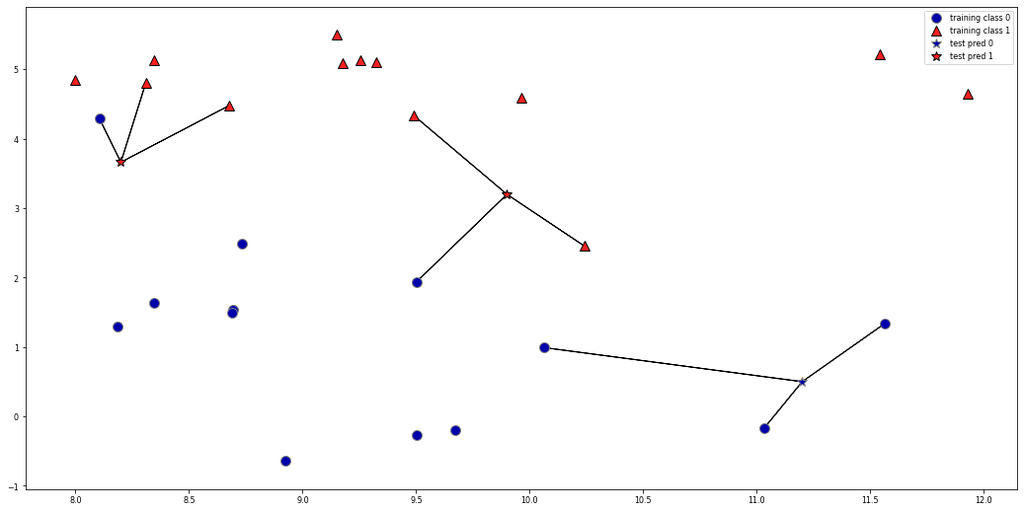

#### Analysis

We can plot the prediction for each possible input to see the *decision boundary*

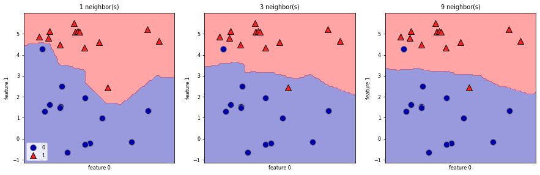

Using few neighbors corresponds to high model complexity (left), and using many neighbors corresponds to low model complexity and smoother decision boundary (right).

### Nearest Shrunken Centroid

- Nearest Centroid: Represents each class by the centroid of its members.
  - Parameteric model (while kNN is non-parametric)
- Regularization is possible with the `shrink_threshold` parameter
  - Shrinks (scales) each feature value by within-class variance of that feature
  - Soft thresholding: if feature value falls below threshold, it is set to 0
  - Effectively removes (noisy) features

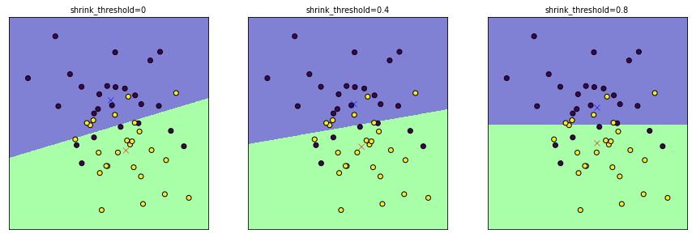

Note: Nearest Centroid suffers when the data is not 'convex'

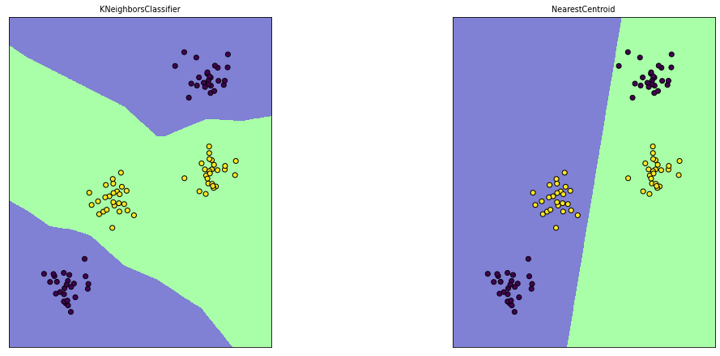

#### Scalability

With n = nr examples and p = nr features

- Nearest shrunken threshold
  - Fit: $O(n * p)$
  - Memory: $O(nrclasses * p)$
  - Predict: $O(nrclasses * p)$
- Nearest neighbors (naive)
  - Fit: $0$
  - Memory: $O(n * p)$
  - Predict: $O(n * p)$
- Nearest neighbors (with KD trees)
  - Fit: $O(p * n log n)$
  - Memory: $O(n * p)$
  - Predict: $O(k * log n)$

## k-Neighbors Regression

k=1: return the target value of the nearest neighbor (overfits easily)  
k>1: return the *mean* of the target values of the *k* nearest neighbors

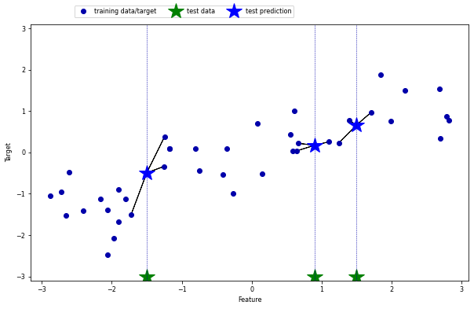

#### Analysis

We can again output the predictions for each possible input, for different values of *k*.

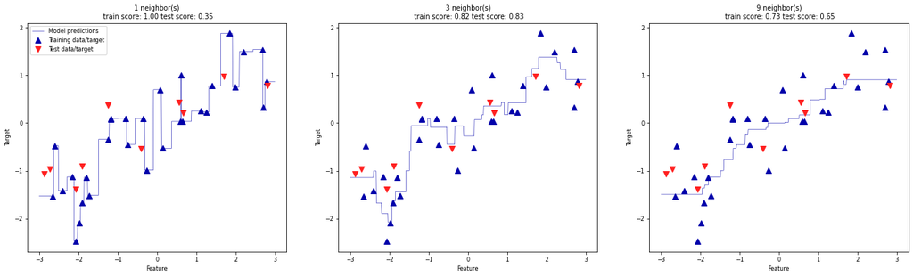

We see that again, a small *k* leads to an overly complex (overfitting) model, while a larger *k* yields a smoother fit.

## kNN: Strengths, weaknesses and parameters

- Easy to understand, works well in many settings
- Training is very fast, predicting is slow for large datasets
- Bad at high-dimensional and sparse data (curse of dimensionality)
- Nearest centroid is a useful parametric alternative, but only if data is (near) linearly separable.